# Figure 4C — Seahorse XF OCR Trace (P45: Sal-N vs LPS-Hx)

Kratimenos Lab

01 June 2026

# Overview

Panel C compares the **mean oxygen consumption rate (OCR) trace** for the **P45 Sal-N (control)** and **P45 LPS-Hx** groups across the Seahorse XF Mito Stress Test injection sequence.

```r
library(tidyverse)
library(ggtext)
library(knitr)

theme_panel <- theme_classic(base_size = 13, base_family = "Arial") +
  theme(
    panel.grid         = element_blank(),
    legend.position    = "none",
    axis.title.y       = element_text(size = 13, margin = margin(r = 5)),
    axis.title.x       = element_text(size = 13, margin = margin(t = 5)),
    axis.text          = element_text(size = 12, color = "black"),
    axis.line          = element_line(linewidth = 0.5),
    axis.ticks         = element_line(linewidth = 0.5),
    plot.title         = element_textbox_simple(
                            size = 13, hjust = 0.5, halign = 0.5,
                            face = "bold",
                            fill = "#E8E5EE", color = "grey15",
                            box.color = NA,
                            padding = margin(4, 8, 4, 8),
                            margin  = margin(0, 0, 8, 0),
                            r = unit(2, "pt"),
                            width = grid::unit(0.55, "npc")),
    plot.margin        = margin(6, 10, 6, 6)
  )
```

# Load time-course data

```r
trace <- readxl::read_excel("data/Fig4ABC_data.xlsx", sheet = "fig4c_trace_group_mean") |>
  mutate(Group = factor(Group, levels = c("Sal-N", "LPS-Hx")))

kable(trace |> group_by(Group) |>
        summarise(n_timepoints = n(),
                  OCR_min      = round(min(OCR), 1),
                  OCR_max      = round(max(OCR), 1),
                  OCR_baseline = round(mean(OCR[time_min < 50]), 1)),
      caption = "Per-group trace summary (group mean ± SEM, n = 6 each)")
```

Per-group trace summary (group mean ± SEM, n = 6 each)

| Group | n_timepoints | OCR_min | OCR_max | OCR_baseline |
| --- | --- | --- | --- | --- |
| Sal-N | 45 | 18.5 | 141.7 | 133.2 |
| LPS-Hx | 45 | 27.5 | 147.2 | 143.0 |

# Phase boundaries

Injection times derived from the change-points in the trace:

[output not shown]

```r
# `hjust = -0.05` puts the label to the right of the vertical line; `hjust = 1.05`
# puts it to the left. A/R sits at the rightmost line, so it gets a right-aligned
# label so the text doesn't get clipped against the plot edge.
injections <- tibble(
  x     = c(56.4, 211.4, 297.9),   # midpoints between adjacent measurements
  label = c("Oligomycin", "FCCP", "A/R"),
  hjust = c(-0.05, -0.05, 1.05)
)
```

# Figure 4C — overlay

Sal-N and LPS-Hx group-mean traces overlaid. Light-blue calibration band at the start, green vertical injection markers, “Proton leak” bracket over the post-oligomycin window. Legend at top-right.

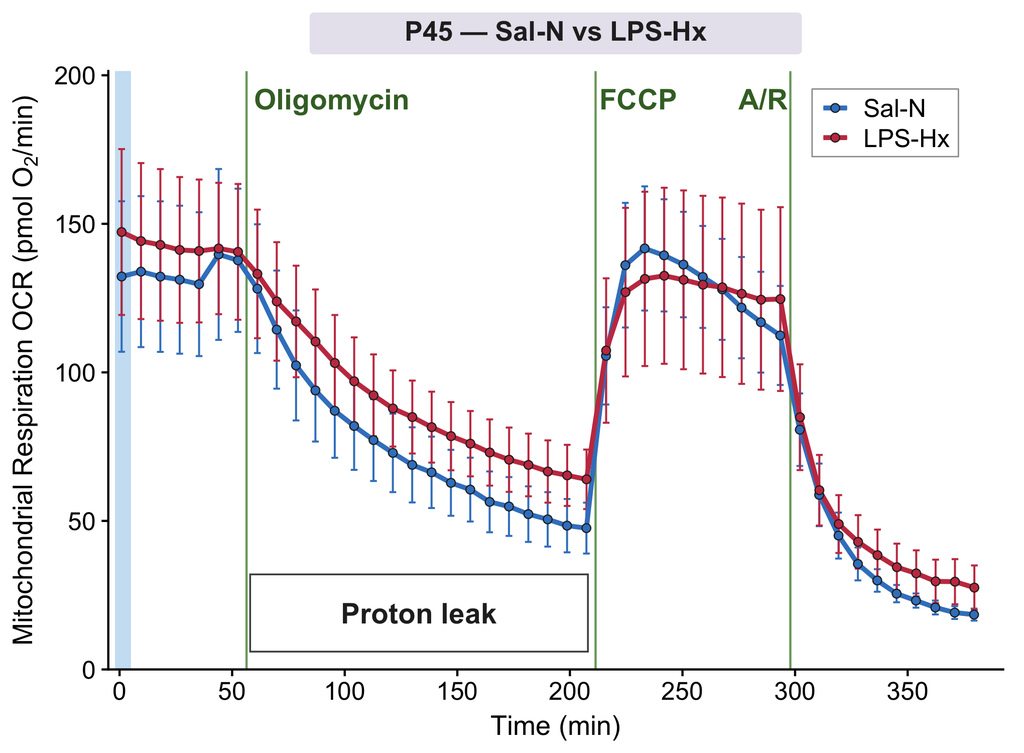

Figure 4C. Seahorse XF OCR traces for P45 Sal-N (control, blue) and P45 LPS-Hx (red, n = 6 mice each) — group mean ± SEM at each measurement time-point. Light-blue band: calibration. Green vertical lines: injections (Oligomycin, FCCP, A/R). The bracketed region marks the proton-leak phase quantified in Panel B.

```r
group_color <- c("Sal-N" = "#3C82C7", "LPS-Hx" = "#C73C50")
group_fill_dot <- c("Sal-N" = "#3C82C7", "LPS-Hx" = "#C73C50")

x_max  <- max(trace$time_min) + 5
y_max  <- max(trace$OCR + trace$SEM, na.rm = TRUE) * 1.15

# Proton-leak bracket — span the slow-decline post-oligomycin window
proton_y_top <- 32
proton_y_bot <- 6

p4c <- ggplot(trace, aes(x = time_min, y = OCR, color = Group, fill = Group)) +
  annotate("rect", xmin = -2, xmax = 5, ymin = 0, ymax = y_max,
           fill = "#9EC9E9", alpha = 0.55, color = NA) +
  geom_vline(data = injections, aes(xintercept = x),
             linetype = "solid", linewidth = 0.5,
             color = "#7AA56C", inherit.aes = FALSE) +
  geom_text(data = injections,
            aes(x = x, y = y_max * 0.97, label = label, hjust = hjust),
            inherit.aes = FALSE,
            size = 4.8, fontface = "bold",
            vjust = 1, color = "#3F6E2F") +
  geom_errorbar(aes(ymin = OCR - SEM, ymax = OCR + SEM),
                width = 3, linewidth = 0.45) +
  geom_line(linewidth = 1.1) +
  geom_point(shape = 21, color = "grey15", size = 1.7, stroke = 0.4) +
  annotate("rect", xmin = 58, xmax = 208,
           ymin = proton_y_bot, ymax = proton_y_top,
           fill = "white", color = "grey30", linewidth = 0.4) +
  annotate("text", x = (58 + 208)/2, y = (proton_y_bot + proton_y_top)/2,
           label = "Proton leak",
           size = 4.8, fontface = "bold", color = "grey15") +
  scale_color_manual(values = group_color, name = NULL) +
  scale_fill_manual (values = group_fill_dot, name = NULL) +
  scale_x_continuous(limits = c(-5, x_max),
                     breaks = seq(0, x_max, 50),
                     expand = expansion(mult = c(0, 0.02))) +
  scale_y_continuous(limits = c(0, y_max),
                     expand = expansion(mult = c(0, 0))) +
  labs(x = "Time (min)",
       y = expression("Mitochondrial Respiration OCR (pmol O"[2]*"/min)"),
       title = "P45 — Sal-N vs LPS-Hx") +
  theme_panel +
  theme(
    legend.position    = c(0.95, 0.97),
    legend.justification = c(1, 1),
    legend.background  = element_rect(fill = "white", color = "grey60",
                                      linewidth = 0.3),
    legend.key.size    = unit(0.5, "cm"),
    legend.text        = element_text(size = 12),
    legend.margin      = margin(2, 4, 2, 4)
  )

p4c
```

```r
ggsave("Fig4C.pdf", plot = p4c, width = 6.8, height = 5.0,
       device = cairo_pdf)
ggsave("Fig4C.png", plot = p4c, width = 6.8, height = 5.0, dpi = 300, bg = "white")
```

# Per-phase summary (validation)

```r
trace |>
  mutate(phase = case_when(
    time_min <  56.4 ~ "1. Basal",
    time_min < 211.4 ~ "2. Post-Oligomycin (proton leak)",
    time_min < 297.9 ~ "3. Post-FCCP (max respiration)",
    TRUE             ~ "4. Post-A/R (non-mitochondrial)"
  )) |>
  group_by(Group, phase) |>
  summarise(
    n_timepoints = n(),
    OCR_mean = round(mean(OCR), 1),
    OCR_min  = round(min(OCR),  1),
    OCR_max  = round(max(OCR),  1),
    .groups = "drop"
  ) |>
  arrange(phase, Group) |>
  kable(caption = "Per-phase OCR summary by group")
```

Per-phase OCR summary by group

| Group | phase | n_timepoints | OCR_mean | OCR_min | OCR_max |
| --- | --- | --- | --- | --- | --- |
| Sal-N | 1. Basal | 7 | 133.8 | 129.7 | 139.7 |
| LPS-Hx | 1. Basal | 7 | 142.7 | 140.6 | 147.2 |
| Sal-N | 2. Post-Oligomycin (proton leak) | 18 | 73.7 | 47.6 | 128.2 |
| LPS-Hx | 2. Post-Oligomycin (proton leak) | 18 | 88.6 | 64.0 | 133.1 |
| Sal-N | 3. Post-FCCP (max respiration) | 10 | 127.0 | 105.5 | 141.7 |
| LPS-Hx | 3. Post-FCCP (max respiration) | 10 | 126.3 | 107.3 | 132.5 |
| Sal-N | 4. Post-A/R (non-mitochondrial) | 10 | 35.7 | 18.5 | 80.7 |
| LPS-Hx | 4. Post-A/R (non-mitochondrial) | 10 | 42.9 | 27.5 | 84.9 |

# Notes

- **Qualitative panel** — no group statistics. Panels A and B carry the proton-leak quantification (one-way ANOVA + Tukey HSD).
- **Phase definitions** (computed downstream by Wave’s Mito Stress Test report):
  - **Basal respiration** = OCR(baseline) − OCR(A/R)
  - **ATP-linked respiration** = OCR(baseline) − OCR(post-Oligomycin)
  - **Proton leak** = OCR(post-Oligomycin) − OCR(post-A/R) (this is what is plotted in Fig 4A and 4B)
  - **Maximal respiration** = OCR(post-FCCP) − OCR(post-A/R)
  - **Spare respiratory capacity (SRC)** = OCR(post-FCCP) − OCR(baseline)